# Workshop 6: Regression discontinuity

Carlos Daboín

5/31/2022

# Caso 1. Elecciones cercanas

¿Quién definen las políticas públicas en democracia ?: ¿Los votantes o los políticos?

- La teoría de la **convergencia** política propone que los candidatos tenderán a moderar sus posturas personales para hacerlas mas compatibles a su electorado (i.e, Cercanas al votante mediano) y aumentar sus chances de ser electo (o re-electo).
- La teoría de la **divergencia** política propone que luego de ser electos, los políticos se decantan por sus políticas preferidas, ya que no hay mecanismos post-elctorales que compromentan al nuevo funcionario con las promesas hechas en la campaña.
- **El experimento ideal:** Sería genial si contáramos con varias regiones con preferencias políticas idénticas a las que les pudieramos asignar representantes de distintos partidos. Si vemos que al asignar un candidato demócrata los votos en el Congreso son mas “liberales” que en promedio, podremos confirmar que hay divergencia política.

Revisaremos datos provenientes de los siguientes estudios:

- Lee, David S., Enrico Moretti, and Matthew J. Butler. 2004. “Do Voters Affect or Elect Policies: Evidence from the u.s. House.” Quarterly Journal of Economics 119 (3): 807–59. [link](https://eml.berkeley.edu/~moretti/final.pdf)
- El paper es revisado con detalle en Causal Inferece: The Mixtape, sección 6.14.

**Premisa:** En las elecciones legislativas de EE.UU. se eligen los candidatos con la mayoria simple de los votos. Es plausible suponer que las preferencias de los ciudadanos en los condados donde el candidato Demócrata obtuvo cerca del 50% de los votos son muy símilares, y por ende comparables.

## Empecemos

Instalemos y activemos los paquetes necesarios.

```r
## Install packages:
# Usa este código para instalar los paquetes que te falten
# install.packages("tidyverse")
# install.packages("cli")
# install.packages("haven")
# install.packages("stargazer")
# install.packages("fixest")

# Para esta clase
# install.packages("modelsummary")
# install.packages("estimatr")
# install.packages("rdd")
# install.packages("rdrobust")
# install.packages("rddensity")
```

```r
library(haven)
library(tidyverse)
library(estimatr)
library(fixest)

# This chapter only
library(modelsummary)
library(rdd)
library(rdrobust)
library(rddensity)

# read_data function  (la usamos para descargar datos del repositorio github de Scott Cuningham)
read_data <- function(df) {
  full_path <- paste0("https://raw.github.com/scunning1975/mixtape/master/", df)
  return(haven::read_dta(full_path))
}
```

Leamos la data y guardémosla en un objeto de R.

```r
### Leamos la data y guardémosla en un objeto de R
#### Fijate que la estás leyendo directamente desde un repositorio (ver cómo creamos la función read_data()), asi que necesitas conexión a intenet para leerla

lmb_data <- read_data("lmb-data.dta")
```

Revisemos la estructura de la data y comentémos los hallazgos:

```r
## Démosle un vistazo rápido a la data
### Tiene un montón de variables, pero no se alarmen: Usarémos unas pocas
head(lmb_data %>%
          select(id, n,name,year,score,
                 state, district, incmbncy,
                 democrat,
                 demvote, repvote,
                 demvoteshare,lagdemvoteshare,
                 democrat,lagdemocrat))
```

```
## # A tibble: 6 x 14
##      id     n name       year score     state district incmbncy democrat demvote
##   <dbl> <dbl> <chr>     <dbl> <dbl> <dbl+lbl>    <dbl> <dbl+lb>    <dbl>   <dbl>
## 1     3     1 RIBICOFF,  1948  64.3 1 [01: C~        1 -1 [-1:~        1  127802
## 2     4     2 RIBICOFF,  1948  60.3 1 [01: C~        1 -1 [-1:~        1  127802
## 3     5     1 RIBICOFF,  1950  57.1 1 [01: C~        1  1 [1: ~        1  134258
## 4     6     2 RIBICOFF,  1950  73.8 1 [01: C~        1  1 [1: ~        1  134258
## 5     7     1 DODD       1954  43.0 1 [01: C~        1  1 [1: ~        1  148935
## 6     8     2 DODD       1954  74.3 1 [01: C~        1  1 [1: ~        1  148935
## # ... with 4 more variables: repvote <dbl>, demvoteshare <dbl>,
## #   lagdemvoteshare <dbl>, lagdemocrat <dbl>
```

**Descripción de variables:**

```r
## Veamos las estadísticas descriptivas de estas variables. No red flags
summary(lmb_data %>%
          select(id, year,state, district, incmbncy,
                 demvote, repvote,
                 score,demvoteshare,lagdemvoteshare,
                 democrat,lagdemocrat))
```

```
##        id             year          state          district
##  Min.   :    3   Min.   :1948   Min.   : 1.00   Min.   : 1.00
##  1st Qu.: 4258   1st Qu.:1958   1st Qu.:14.00   1st Qu.: 3.00
##  Median : 8358   Median :1970   Median :33.00   Median : 7.00
##  Mean   : 8499   Mean   :1969   Mean   :35.27   Mean   :10.91
##  3rd Qu.:12790   3rd Qu.:1980   3rd Qu.:49.00   3rd Qu.:14.00
##  Max.   :17128   Max.   :1990   Max.   :82.00   Max.   :99.00
##
##     incmbncy          demvote           repvote            score
##  Min.   :-1.0000   Min.   :      0   Min.   :      0   Min.   :-27.92
##  1st Qu.:-1.0000   1st Qu.:  50708   1st Qu.:  33683   1st Qu.: 11.30
##  Median : 1.0000   Median :  71084   Median :  62823   Median : 37.95
##  Mean   : 0.1656   Mean   :  76349   Mean   :  65162   Mean   : 41.90
##  3rd Qu.: 1.0000   3rd Qu.:  96255   3rd Qu.:  91187   3rd Qu.: 72.78
##  Max.   : 3.0000   Max.   :1872351   Max.   :1716480   Max.   :128.85
##  NA's   :6         NA's   :10        NA's   :11
##   demvoteshare    lagdemvoteshare     democrat       lagdemocrat
##  Min.   :0.0000   Min.   :0.0000   Min.   :0.0000   Min.   :0.0000
##  1st Qu.:0.4156   1st Qu.:0.4107   1st Qu.:0.0000   1st Qu.:0.0000
##  Median :0.5571   Median :0.5463   Median :1.0000   Median :1.0000
##  Mean   :0.5819   Mean   :0.5768   Mean   :0.5967   Mean   :0.5827
##  3rd Qu.:0.7196   3rd Qu.:0.7118   3rd Qu.:1.0000   3rd Qu.:1.0000
##  Max.   :1.0000   Max.   :1.0000   Max.   :1.0000   Max.   :1.0000
##  NA's   :11       NA's   :11
```

## Resultados originales

Estimamos $\delta$ en una muestra de la data filtrada en $+\-$ 2 puntos por encima de 50%

$$Y_{i}=\alpha+\delta D_{i}+\varepsilon_{i}$$

```r
## Fíjense que estamos usando un nuevo comando llamado lm_roboust
## Este comando sirve para calcular errores estándar robustos o para agrupar (cluster) errores estándar. No se preocupen por el motivo detrás de esto por el momento.

lmb_subset <- lmb_data %>%
  filter(lagdemvoteshare>.48 & lagdemvoteshare<.52)

lm_1 <- feols(score ~ lagdemocrat, data = lmb_subset)
lm_2 <- feols(score ~ democrat, data = lmb_subset)
lm_3 <- feols(democrat ~ lagdemocrat, data = lmb_subset)

#"Original results based on ADA Scores -- Close Elections Sample"

msummary(list("ADA Score t+1"=lm_1,
              "ADA Score t"=lm_2,
              "Democrat t+1"=lm_3),
         vcov = 'robust',
         stars = c('*' = .1, '**' = .05, '***' = .01),
         coef_rename = c('lagdemocrat' = 'Demo', 'democrat' = 'Demo'),
         gof_map= modelsummary::gof_map %>%
           filter(raw=="nobs"|raw=="r.squared"))
```

|  | ADA Score t+1 | ADA Score t | Democrat t+1 |
| --- | --- | --- | --- |
| (Intercept) | 31.196*** | 18.747*** | 0.242*** |
|  | (1.335) | (0.844) | (0.020) |
| Demo | 21.284*** | 47.706*** | 0.484*** |
|  | (1.953) | (1.358) | (0.029) |
| Num.Obs. | 915 | 915 | 915 |
| R2 | 0.115 | 0.578 | 0.235 |

* p < 0.1, ** p < 0.05, *** p < 0.01

El efecto de una victoria Demócrata:

- Incrementa el voto liberal del próximo período en en 21 puntos.
- Incrementa el voto liberal del período actual en 48 puntos.
- Incrementa la probabilidad de reeleción demócrata en 48 puntos porcentuales en las próximas elecciones.

Hay evidencia de divergencia (políticos se alejan del “centro” ideológico apenas son electos) y de ventaja de incumbentes (los ganadores tienen efecto positivo en las próximas elecciones de su partido). Asegurémonos de que estos resultados no se dieron por casualidad. Tratemos de replicar estos resultados con especificaciones que se aprovechen de toda la data y ver si llegamos a conclusiones similares.

## Resultados usando toda la data

Fíjate que si usamos la misma especificación usando toda la data obtenemos resultados muy distintos.

```r
#using all data (note data used is lmb_data, not lmb_subset)
lm_1 <- feols(score ~ lagdemocrat, data = lmb_data)
lm_2 <- feols(score ~ democrat, data = lmb_data)
lm_3 <- feols(democrat ~ lagdemocrat, data = lmb_data)

# "Results based on ADA Scores -- Full Sample"
msummary(list("ADA Score t+1"=lm_1,
              "ADA Score t"=lm_2,
              "Democrat t+1"=lm_3),
         vcov = 'robust',
         stars = c('*' = .1, '**' = .05, '***' = .01),
         coef_rename = c('lagdemocrat' = 'Demo', 'democrat' = 'Demo'),
         gof_map= modelsummary::gof_map %>%
           filter(raw=="nobs"|raw=="r.squared"))
```

|  | ADA Score t+1 | ADA Score t | Democrat t+1 |
| --- | --- | --- | --- |
| (Intercept) | 23.539*** | 17.576*** | 0.120*** |
|  | (0.337) | (0.263) | (0.004) |
| Demo | 31.506*** | 40.763*** | 0.818*** |
|  | (0.484) | (0.418) | (0.005) |
| Num.Obs. | 13588 | 13588 | 13588 |
| R2 | 0.227 | 0.376 | 0.676 |

* p < 0.1, ** p < 0.05, *** p < 0.01

Incluir data alejada del punto de corte induce cambios importantes en los resultados.

### Resultados usando toda la data y añadiento la “running variable” como control

Véamos que pasa si añadimos la tasa de votos demócratas como variable de control (centrada alrededor de cero).

$$Y_{i}=\alpha+\beta\left(X_{i}-c_{0}\right)+\delta D_{i}+\varepsilon_{i}$$

```r
## Actualicemos la variable data con una nueva columna que sea el porcentaje que obtuvieron los demócratas centrado en cero
lmb_data<-lmb_data %>%
  mutate(demvoteshare_c=demvoteshare-0.5)

### Pregunta de R: Fijate que actualizamos lmb_data. ¿Crees que lmb_subset se actualizó también? ¿Si o no?


lm_1 <- feols(score ~ lagdemocrat + demvoteshare_c, data = lmb_data, clusters = id)
lm_2 <- feols(score ~ democrat + demvoteshare_c, data = lmb_data, clusters = id)
lm_3 <- feols(democrat ~ lagdemocrat + demvoteshare_c, data = lmb_data, clusters = id)

#"Results based on ADA Scores -- Full Sample-- adding centered democrats' vote share"
msummary(list("ADA Score t+1"=lm_1,
              "ADA Score t"=lm_2,
              "Democrat t+1"=lm_3),
         vcov = 'robust',
         stars = c('*' = .1, '**' = .05, '***' = .01),
         coef_rename = c('lagdemocrat' = 'Demo', 'democrat' = 'Demo'),
         gof_map= modelsummary::gof_map %>%
           filter(raw=="nobs"|raw=="r.squared"))
```

|  | ADA Score t+1 | ADA Score t | Democrat t+1 |
| --- | --- | --- | --- |
| (Intercept) | 22.883*** | 11.034*** | 0.212*** |
|  | (0.443) | (0.336) | (0.005) |
| Demo | 33.451*** | 58.502*** | 0.552*** |
|  | (0.848) | (0.656) | (0.010) |
| demvoteshare_c | -5.626*** | -48.938*** | 0.773*** |
|  | (1.899) | (1.642) | (0.019) |
| Num.Obs. | 13577 | 13577 | 13577 |
| R2 | 0.227 | 0.424 | 0.735 |

* p < 0.1, ** p < 0.05, *** p < 0.01

Aun hay diferencias importantes. Pareciera que estamos sobreestimando los efectos. El efecto en la reelección demócrata es el que menos padece de este problema.

### Resultados usando toda la data e interacciones con la “running variable”

Las interacciones entran al modelo de esta forma

$$Y_{i}=\alpha+\beta\left(X_{i}-c_{0}\right)+\delta D_{i}+\gamma \left(X_{i}-c_{0}\right)*D_{i}+\varepsilon_{i}$$

```r
lm_1 <- feols(score ~ lagdemocrat*demvoteshare_c,
                  data = lmb_data)
lm_2 <- feols(score ~ democrat*demvoteshare_c,
                  data = lmb_data)
lm_3 <- feols(democrat ~ lagdemocrat*demvoteshare_c,
                  data = lmb_data)

# "Results based on ADA Scores -- Full Sample with linear interactions"
msummary(list("ADA Score t+1"=lm_1,
              "ADA Score t"=lm_2,
              "Democrat t+1"=lm_3),
         vcov = 'robust',
         stars = c('*' = .1, '**' = .05, '***' = .01),
         coef_rename = c('lagdemocrat' = 'Demo', 'democrat' = 'Demo',
                         'demvoteshare_c'='Share_c',
                         'democrat:demvoteshare_c'='Demo X Share_c',
                         'lagdemocrat:demvoteshare_c'='Demo X Share_c'),
         gof_map= modelsummary::gof_map %>%
           filter(raw=="nobs"|raw=="r.squared"))
```

|  | ADA Score t+1 | ADA Score t | Democrat t+1 |
| --- | --- | --- | --- |
| (Intercept) | 31.435*** | 16.816*** | 0.287*** |
|  | (0.541) | (0.419) | (0.008) |
| Demo | 30.508*** | 55.431*** | 0.526*** |
|  | (0.818) | (0.638) | (0.010) |
| Share_c | 66.042*** | -5.683** | 1.403*** |
|  | (3.163) | (2.612) | (0.044) |
| Demo X Share_c | -96.475*** | -55.152*** | -0.849*** |
|  | (3.855) | (3.221) | (0.049) |
| Num.Obs. | 13577 | 13577 | 13577 |
| R2 | 0.267 | 0.434 | 0.749 |

* p < 0.1, ** p < 0.05, *** p < 0.01

Parece que nos acercamos más a los resultados originales (menos sobreestimación), pero aún falta.

### Resultados usando toda la data e interacciones cuadráticas con la “running variable”.

El modelo ahora seria asi:

$$Y_{i}=\alpha+\delta D_{i}+\sum_{k=1}^{2} \beta^{k}\left(X_{i}-c_{0}\right)^{k}+\sum_{k=1}^{2} \gamma^{k}\left(X_{i}-c_{0}\right)^{k} * D_{i}+\epsilon_{i}$$

```r
lmb_data <- lmb_data %>%
  mutate(demvoteshare_sq = demvoteshare_c^2)

lm_1 <- feols(score ~ lagdemocrat*demvoteshare_c + lagdemocrat*demvoteshare_sq,
                  data = lmb_data)
lm_2 <- feols(score ~ democrat*demvoteshare_c + democrat*demvoteshare_sq,
                  data = lmb_data)
lm_3 <- feols(democrat ~ lagdemocrat*demvoteshare_c + lagdemocrat*demvoteshare_sq,
                  data = lmb_data)


# "Results based on ADA Scores -- Full Sample with linear and quadratic interactions"
msummary(list("ADA Score t+1"=lm_1,
              "ADA Score t"=lm_2,
              "Democrat t+1"=lm_3),
         vcov = 'robust',
         stars = c('*' = .1, '**' = .05, '***' = .01),
         coef_rename = c('lagdemocrat' = 'Demo', 'democrat' = 'Demo',
                         'demvoteshare_c'='Share_c',
                         'democrat:demvoteshare_c'='Demo X Share_c',
                         'lagdemocrat:demvoteshare_c'='Demo X Share_c',
                         'democrat:demvoteshare_sq'='Demo X Share_c^2',
                         'lagdemocrat:demvoteshare_sq'='Demo X Share_c^2'),
         gof_map= modelsummary::gof_map %>%
           filter(raw=="nobs"|raw=="r.squared"))
```

|  | ADA Score t+1 | ADA Score t | Democrat t+1 |
| --- | --- | --- | --- |
| (Intercept) | 33.547*** | 15.606*** | 0.330*** |
|  | (0.721) | (0.575) | (0.013) |
| Demo | 13.030*** | 44.402*** | 0.322*** |
|  | (1.304) | (0.909) | (0.019) |
| Share_c | 134.977*** | -23.850*** | 2.798*** |
|  | (9.943) | (6.717) | (0.200) |
| demvoteshare_sq | 212.127*** | -41.729*** | 4.294*** |
|  | (23.143) | (14.703) | (0.464) |
| Demo X Share_c | 57.055*** | 111.896*** | 0.091 |
|  | (15.683) | (9.785) | (0.246) |
| Demo X Share_c^2 | -641.851*** | -229.954*** | -8.804*** |
|  | (31.880) | (19.561) | (0.527) |
| Num.Obs. | 13577 | 13577 | 13577 |
| R2 | 0.371 | 0.456 | 0.822 |

* p < 0.1, ** p < 0.05, *** p < 0.01

Epa! Ahora como que nos pasamos. Nuestros estimados ahora son inferiores a los originales.

Quizás nos está afectando mucho el hecho de que estamos usando toda la data, incluyendo la de los extremos. Es plausible que outliers (observaciones los extremos de la data, donde el voto demócrata es muy bajo o muy alto) afecten mucho la distancia observada en la disconinuidad.

**Algunas reflexiones:**

- Fallamos en replicar los resultados de la regresión simple que compara promedios a +/- 2 puntos porcentuales del punto de corte.
- Esto se debe a que les dimos igual peso a todas las observaciones. Pudimos haber probado con métodos que le asignaran más peso a las observaciones mas cercanas al punto de corte.
- Quizás estámos errando en la forma funcional. Pudimos haber optado por un método no paramétrico, es decir, que se ajuste a los datos libremente.
- Todas estas son preguntas que valen la pena hacerse al diseñar estudios de discontinuidad.
- En cualquier caso, todos los coeficientes que obtivimos fueron positivos y estadísticamente significativos, así que ´no todo esta perdido. Quizás nuestros estimadores están un poco sesgados, pero la varianza es aceptable (siempre es positivo y significativamente distinto de cero.)

## Démosle un tour visual al ejercicio

Para nuestros gráficos de discontinuidad necesitaremos dos capas.

- Capa de estimados continuos: Esta es la capa donde mostraremos cómo nuestros modelos se ajustan a los datos del running variable y el outcome variable. Podemos usar la data original para ello.
- Capa de estimados discretos: Esta es la capa calculamos el valor promedio de nuestra variable para distintos intervalos del running variable. Necesitaremos calcular esto en un nuevo data.frame.

### Discontinuidad del ADA Score en t+1

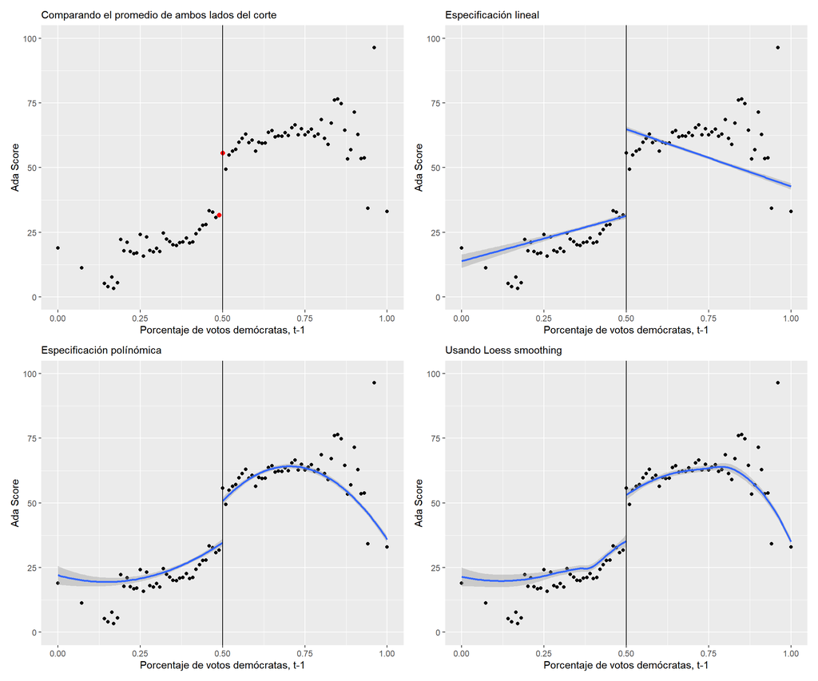

```r
## Para visualizar la discontinuidad del ADA score calculemos su promedio en cada punto porcentual del running variable. Es decir, elegimos 100 ventanas  de longitud 0.01 cada una. Estos datos serviran para la capa de esitmados discretos.

agg_lmb_data<-lmb_data %>%
  mutate(categorias=cut(lagdemvoteshare, 100)) %>%
  group_by(categorias) %>%
  summarise(score=mean(score),
            pctblack=mean(pctblack, na.rm = T),
            medianincome=mean(medianincome, na.rm = T),
            votingpop=mean(votingpop, na.rm = T),
            lagdemvoteshare=min(lagdemvoteshare)) %>%
  ungroup()

## Acá les dejo un código para hacerlo con los comandos nativos de R.
# demmeans <- split(lmb_data$score, cut(lmb_data$lagdemvoteshare, 100)) %>%
#   lapply(mean) %>%
#   unlist()
#
# agg_lmb_data <- data.frame(score = demmeans, lagdemvoteshare = seq(0.01,1, by = 0.01))

#plotting
lmb_data <- lmb_data %>%
  mutate(gg_group = case_when(lagdemvoteshare > 0.5 ~ 1, TRUE ~ 0))

## Lineal
p0<-ggplot(lmb_data , aes(lagdemvoteshare, score)) +
  # la funcion geom point añade la capa de estimados locales,
  # fijate que cada capa puede usar un data.fram diferente, siempre y cuando tengan las columnas que se necesitan
  # en el gráfico (con igual nombre y formato)
  geom_point(aes(x = lagdemvoteshare, y = score), data = agg_lmb_data) +
  geom_point(aes(x = lagdemvoteshare, y = score),fun = mean, colour = "red", size = 2,
               data=agg_lmb_data%>%
             filter(lagdemvoteshare>.49 & lagdemvoteshare<.51))+
  xlim(0,1) + ylim(0,100) +
  geom_vline(xintercept = 0.5) +
  labs(subtitle = "Comparando el promedio de ambos lados del corte",
       x = "Porcentaje de votos demócratas, t-1",
       y= "Ada Score")

## Lineal
p1<-ggplot(lmb_data, aes(lagdemvoteshare, score)) +
  geom_point(aes(x = lagdemvoteshare, y = score), data = agg_lmb_data) +
  # stat_smooth permite añadir un ajuste lineal a los datos. El argumento method the sirve para especificar el método
  # Fijate que usamos el argumento group. Esto nor sirva para especificar los grupos de datos que cada capa debe tratar por separado. A efectos de la regresion, esto es lo que define la interaccion
  stat_smooth(aes(lagdemvoteshare, score, group = gg_group), method = "lm") +
  xlim(0,1) + ylim(0,100) +
  geom_vline(xintercept = 0.5)+
  labs(subtitle = "Especificación lineal",
       x = "Porcentaje de votos demócratas, t-1",
       y= "Ada Score")

## Polinomio grado 2
p2<-ggplot(lmb_data, aes(lagdemvoteshare, score)) +
  geom_point(aes(x = lagdemvoteshare, y = score), data = agg_lmb_data) +
  stat_smooth(aes(lagdemvoteshare, score, group = gg_group), method = "lm",
              formula = y ~ x + I(x^2)) +
  xlim(0,1) + ylim(0,100) +
  geom_vline(xintercept = 0.5)+
  labs(subtitle = "Especificación polínómica",
       x = "Porcentaje de votos demócratas, t-1",
       y= "Ada Score")

# Método densidad local "LOESS"
p3<-ggplot(lmb_data, aes(lagdemvoteshare, score)) +
  geom_point(aes(x = lagdemvoteshare, y = score), data = agg_lmb_data) +
  stat_smooth(aes(lagdemvoteshare, score, group = gg_group), method = "loess") +
  xlim(0,1) + ylim(0,100) +
  geom_vline(xintercept = 0.5)+
  labs(subtitle = "Usando Loess smoothing",
       x = "Porcentaje de votos demócratas, t-1",
       y= "Ada Score")

library(patchwork)
(p0+p1)/(p2+p3)
```

```r
## Desafío para la casa. Hagan lo mismo para ver el impacto sobre las variables democrats (porcentaje de democratas electos en el periodo t)
```

### Probando el balance de otras covariables

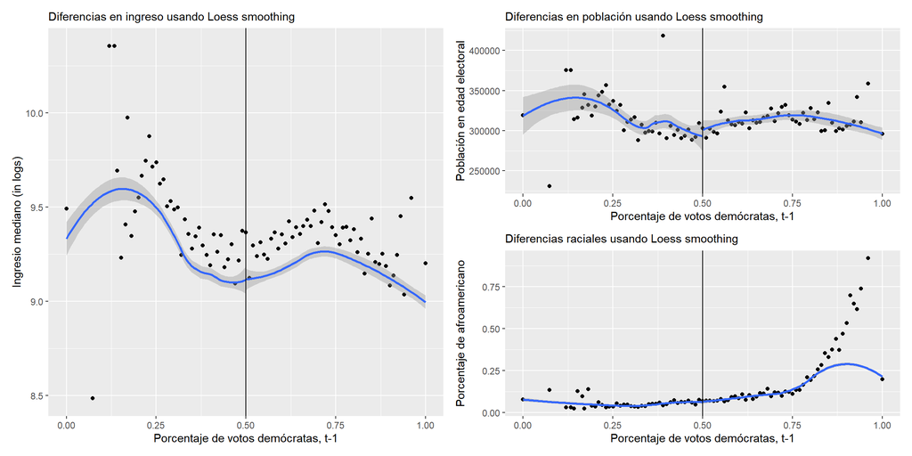

```r
cov_1<-ggplot(lmb_data, aes(lagdemvoteshare, log(medianincome))) +
  geom_point(aes(x = lagdemvoteshare, y = log(medianincome)), data = agg_lmb_data) +
  stat_smooth(aes(lagdemvoteshare, y=log(medianincome), group = gg_group), method = "loess") +
  xlim(0,1) +
  geom_vline(xintercept = 0.5)+
  labs(subtitle = "Diferencias en ingreso usando Loess smoothing",
       x = "Porcentaje de votos demócratas, t-1",
       y= "Ingresio mediano (in logs)")
cov_2<-ggplot(lmb_data, aes(lagdemvoteshare, votingpop)) +
  geom_point(aes(x = lagdemvoteshare, y = votingpop), data = agg_lmb_data) +
  stat_smooth(aes(lagdemvoteshare, y=votingpop, group = gg_group), method = "loess") +
  xlim(0,1) +
  geom_vline(xintercept = 0.5)+
  labs(subtitle = "Diferencias en población usando Loess smoothing",
       x = "Porcentaje de votos demócratas, t-1",
       y= "Población en edad electoral")

cov_3<-ggplot(lmb_data, aes(lagdemvoteshare, pctblack)) +
  geom_point(aes(x = lagdemvoteshare, y = pctblack), data = agg_lmb_data) +
  stat_smooth(aes(lagdemvoteshare, y=pctblack, group = gg_group), method = "loess") +
  xlim(0,1) +
  geom_vline(xintercept = 0.5)+
  labs(subtitle = "Diferencias raciales usando Loess smoothing",
       x = "Porcentaje de votos demócratas, t-1",
       y= "Porcentaje de afroamericano")

cov_1+cov_2/ cov_3
```